# Teste de Hipótese com GitHub (2016-2017)

# Os Dados

```
file_extension: A extensão do arquivo.
```

```r
data %>% select(file_extension) %>% unique
```

```
## # A tibble: 42 x 1
##    file_extension
##    <chr>
##  1 md
##  2 js
##  3 json
##  4 html
##  5 py
##  6 java
##  7 css
##  8 xml
##  9 txt
## 10 yml
## # ... with 32 more rows
```

Como é possível ver no resumo acima, temos extensões para scripts, imagens, textos, etc.

```
month_day, the_month, the_year: Dia, mês e ano respectivamente em que a coleta dos dados foi efetuada.
```

```r
data %>% select(-file_extension, -users) %>% summary()
```

```
##    month_day       the_month         the_year
##  Min.   : 1.00   Min.   : 1.000   Min.   :2016
##  1st Qu.: 8.00   1st Qu.: 3.000   1st Qu.:2016
##  Median :15.00   Median : 4.000   Median :2016
##  Mean   :15.49   Mean   : 5.427   Mean   :2016
##  3rd Qu.:23.00   3rd Qu.: 8.000   3rd Qu.:2017
##  Max.   :31.00   Max.   :12.000   Max.   :2017
```

Temos dados desde 2016 até 2017, como falado anteriormente.

```
users: Quantidade de usuários que modificaram aquele tipo de arquivo até a data da coleta.
```

```r
data %>% select(users) %>% summary()
```

```
##      users
##  Min.   :  501
##  1st Qu.:  763
##  Median : 1520
##  Mean   : 2151
##  3rd Qu.: 2782
##  Max.   :10279
```

Como possível visualizar acima, temos tipos de arquivos que tiveram **501** usuários mas também temos outros que tiveram **10279** usuários.

# Conceitos

## Hipótese Nula

É a hipótese assumida como verdadeira para a construção do teste. É uma hipótese que é apresentada sobre determinados eventos estatísticos e cuja falsidade se tenta provar através de um teste de hipóteses.

## Teste de permutação

A partir de um processo aleatório, criamos uma amostra em que não há associação e portanto, geramos a hipótese nula.

## Teste de Hipótese

É um procedimento estatístico que permite tomar uma decisão (aceitar ou rejeitar a hipótese nula) entre duas ou mais hipóteses (hipótese nula ou hipótese alternativa), utilizando os dados observados de um determinado experimento.

## P-Valor

O *p-valor* é a probabilidade de se obter uma estatística de teste igual ou mais extrema que aquela observada em uma amostra, sob a hipótese nula.

Uma outra interpretação para o *p-valor*, é que é menor nível de significância com que se rejeitaria a hipótese nula. Em outras palavras, um *p-valor* pequeno significa que a probabilidade de obter um valor da estatística de teste como o observado é muito improvável, por isso a hipótese nula é rejeitada.

## Nível de Significância - Alfa

É o limite que se toma como base para afirmar que uma certa diferença é decorrente do acaso ou não. Em outras palavras, é a probabilidade de rejeitar a hipótese nula quando ela é verdadeira. Por exemplo, um nível de significância de 0,05 indica um risco de 5% de concluir que existe uma diferença quando não há diferença real.

# Pergunta

## Existe uma diferença entre a quantidade de commits efetuados quando comparamos os dias de segundas e sextas com as terças, quartas e quintas?

Para responder a esta pergunta iremos utilizar apenas commits realizados em arquivos que são de linguagens de programação.

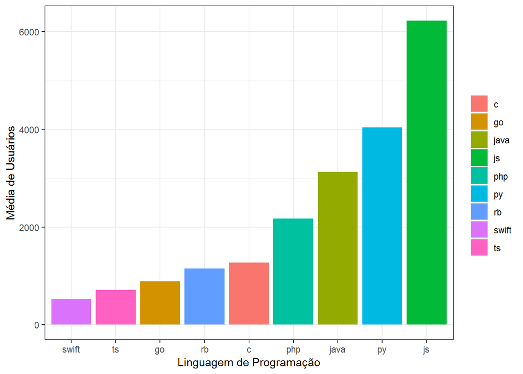

```r
languages %>%
  filter(file_extension %in% some_programming_languages) %>%
  group_by(file_extension) %>%
  summarise(users_mean = mean(users)) %>%
    ggplot(aes(
      x = reorder(file_extension, users_mean),
      y = users_mean,
      fill = file_extension)) +
    geom_bar(stat = "identity") +
    labs(x = "Linguagem de Programação", y = "Média de Usuários") +
    guides(fill=guide_legend(title=NULL))
```

Além disso, iremos utilizar como *estimador* a diferença não pareada (TRUE-FALSE) indicando se é Segunda e Sexta ou não (Se for Terça, Quarta ou Quinta).

```r
seg_sex <- c("segunda-feira", "sexta-feira")
sab_dom <- c("sábado", "domingo")
languages %>%
  mutate(days = if_else(weekdays(languages$cronology) %in% seg_sex, "SEG-SEX", "TER-QUA-QUI")) %>%
  filter(weekdays(languages$cronology) %in% sab_dom != TRUE) %>%
  filter(file_extension %in% some_programming_languages) -> languages_days

languages_days %>%
  sample_n(10)
```

```
## # A tibble: 10 x 7
##    file_extension month_day the_month the_year users cronology  days
##    <chr>              <int>     <int>    <int> <int> <date>     <chr>
##  1 java                  30         3     2017  3759 2017-03-30 TER-QUA-Q~
##  2 go                    14         3     2016  1019 2016-03-14 SEG-SEX
##  3 php                   13         5     2016  2658 2016-05-13 SEG-SEX
##  4 ts                    16        11     2016   872 2016-11-16 TER-QUA-Q~
##  5 rb                     8         5     2017   651 2017-05-08 SEG-SEX
##  6 js                    24         3     2016  7467 2016-03-24 TER-QUA-Q~
##  7 php                   26         4     2017  1696 2017-04-26 TER-QUA-Q~
##  8 ts                    22        12     2016   850 2016-12-22 TER-QUA-Q~
##  9 rb                     7         1     2016  1629 2016-01-07 TER-QUA-Q~
## 10 php                    5         7     2016  2392 2016-07-05 TER-QUA-Q~
```

## Definições

### Hipótese Nula

Não existe diferença significativa entre a quantidade de commits efetuados entre os dias de segundas e sextas e os dias de terças, quartas e quintas.

### Hipótese Alternativa

Existe diferença significativa entre a quantidade de commits efetuados entre os dias de segundas e sextas e os dias de terças, quartas e quintas.

Vamos coletar dados apenas das linguagens de programação vistas mais acima que tiveram suas coletas em dias da semana (entre segunda e sexta).

### Nível de Confiança - Alfa

Usaremos um alfa igual a 0.05 (5%).

### Respondendo…

```r
library(resample)

languages_days %>%
  permutationTest2(statistic = mean(users),
                   treatment = days)
```

```
## Call:
## permutationTest2(data = ., statistic = mean(users), treatment = days)
## Replications: 9999
## Two samples, sample sizes are 1107 1693
##
## Summary Statistics for the difference between samples 1 and 2:
##                                   Observed     Mean Alternative PValue
## mean(users): SEG-SEX-TER-QUA-QUI -149.6336 1.245634   two.sided 0.0092
```

O **p-valor** indicado após a execução do teste de permutação é deveras menor que o nosso nível de confiança (alfa) o que indica que a associação de fato está presente, ou seja, com 95% de confiança nós rejeitamos a **hipótese nula** *(de que não existe diferença significativa entre a quantidade de commits efetuados entre os dias de segundas e sextas e os dias de terças, quartas e quintas)*. Em outras palavras, por dupla negação, não podemos afirmar que não há diferença e portanto, dizemos que há diferença.

### Comparando com CI…

Uma coisa interessante a se mencionar é que no caso de Teste de Hipótese não temos informações suficientes para dizer algo a respeito da relevância ou magnitude das diferenças, apenas podemos dizer se existe ou não. Enquanto que com CI, podemos dizer além do efeito, a sua relevância.